# Training an acoustic model using a Basque dataset

In this notebook we will train an acoustic model of Basque and align the audio files. You can download the corpus from the Google drive and the corpus is already prepared for training, that is, wav and .lab files are already avaliable and located in folders for each speaker. Fortunately, there is already a dictionary available in the MFA repository. Note, that the corpus you downlaoded from the Google Drive is only a snippet of the whole corpus, that is, it contains only files, where all words of the transcription are also present in the available dictionary. The entire Basque corpus can be found [here](https://openslr.org/76/). Download the Basque dictionary by using the following command by using the command line (do not type the ! at the beginning):

```python
!mfa model download dictionary basque_cv
```

For a first run, we will use only the data of one speaker. Create a directory for your corpus and paste one folder. The structure should look like this:

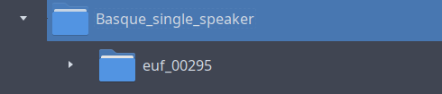

Recall that the directory of your corpus should contain either 1) wav and lab files only, or, if you have multiple speakers, 2) it should contain one folder for each speaker with wav and lab files or TextGrids.

We will validate first if all the words in the transcription are also in the dictionary. In this case, the path to the data is ~/Workspace/corpora/Basque_single_speaker/. Since we use a downlaoded dictionary, we can type in simply basque_cv for the dictionary. The whole command is as follows (adapt the paths to your system):

```python
!mfa validate --clean ~/Workspace/corpora/Basque_single_speaker/ basque_cv
```

```
INFO - Setting up corpus information...
INFO - Loading corpus from source files...
INFO - Found 1 speaker across 21 files, average number of utterances per
                speaker: 21.0
INFO - Initializing multiprocessing jobs...
WARNING - Number of jobs was specified as 3, but due to only having 1 speakers,
                   MFA will only use 1 jobs. Use the --single_speaker flag if
                   you would like to split utterances across jobs regardless of
                   their speaker.
INFO - Normalizing text...
INFO - Creating corpus split for feature generation...
INFO - Generating MFCCs...
INFO - Calculating CMVN...
INFO - Generating final features...
INFO - Creating corpus split with features...

INFO - ******
INFO - Corpus
INFO - ******

INFO -   21 sound files
INFO -   21 text files
INFO -   1 speakers
INFO -   21 utterances
INFO -   116.565 seconds total duration

INFO -   Sound file read errors
INFO -   ======================

INFO -     There were no issues reading sound files.

INFO -   Feature generation
INFO -   ==================

INFO -     There were no utterances missing features.

INFO -   Files without transcriptions
INFO -   ============================

INFO -     There were no sound files missing transcriptions.
```

[output cut: 124 more lines]

```
INFO - Accumulating statistics...
INFO - monophone - Iteration 39 of 40
INFO - Accumulating statistics...
INFO - monophone - Iteration 40 of 40
INFO - Accumulating statistics...
INFO - Training complete!
INFO - Compiling training graphs...
INFO - Generating alignments...
INFO - Accumulating transition stats...
INFO - Finished accumulating transition stats!
INFO - Beginning phone LM training...
INFO - Collecting training data...
INFO - Training model...
INFO - Completed training in 105.73466277122498 seconds!
INFO - Done! Everything took 119.060 seconds
```

```python
# mfa train --clean PATH_TO_YOUR_CORPUS PATH_TO_YOUR_DICTIONARY PATH_TO_ACOUSTIC_MODEL_OUTPUT
```

It is best if the path for the storage of your acoustic model ends with a filename and a .zip suffix. Otherwise all the files and information of your acoustic model will be stored in the folder, not in a .zip archive.

In this case, I will run the command with the followinig specifications:

```python
!mfa  train --clean ~/Workspace/corpora/Basque_single_speaker/ basque_cv ~/Workspace/corpora/My_Basque_AC_model.zip
```

```
WARNING - The previous run had a different configuration than the current, which
                   may cause issues. Please see the log for details or use
                   --clean flag if issues are encountered.
INFO - Setting up corpus information...
INFO - Loading corpus from source files...
INFO - Found 1 speaker across 21 files, average number of utterances per
                speaker: 21.0
INFO - Initializing multiprocessing jobs...
WARNING - Number of jobs was specified as 3, but due to only having 1 speakers,
                   MFA will only use 1 jobs. Use the --single_speaker flag if
                   you would like to split utterances across jobs regardless of
                   their speaker.
INFO - Normalizing text...
INFO - Creating corpus split for feature generation...
INFO - Generating MFCCs...
INFO - Calculating CMVN...
INFO - Generating final features...
INFO - Creating corpus split with features...
INFO - Initializing training for monophone...
INFO - Compiling training graphs...
INFO - Generating initial alignments...
INFO - Initialization complete!
INFO - monophone - Iteration 1 of 40
INFO - Generating alignments...
INFO - Accumulating statistics...
INFO - monophone - Iteration 2 of 40
INFO - Generating alignments...
INFO - Accumulating statistics...
INFO - monophone - Iteration 3 of 40
INFO - Generating alignments...
INFO - Accumulating statistics...
INFO - monophone - Iteration 4 of 40
INFO - Generating alignments...
INFO - Accumulating statistics...
INFO - monophone - Iteration 5 of 40
INFO - Generating alignments...
INFO - Accumulating statistics...
INFO - monophone - Iteration 6 of 40
INFO - Generating alignments...
INFO - Accumulating statistics...
```

[output cut: 530 more lines]

```
INFO - Training complete!
INFO - Exiting training early to save time as the corpus is below the subset
                size for later training stages
INFO - Compiling training graphs...
INFO - Generating alignments...
INFO - Calculating fMLLR for speaker adaptation...
INFO - Generating alignments...
INFO - Accumulating transition stats...
INFO - Finished accumulating transition stats!
INFO - Beginning phone LM training...
INFO - Collecting training data...
INFO - Training model...
INFO - Completed training in 416.2070937156677 seconds!
INFO - Saved model to /home/philipp/Workspace/corpora/My_Basque_AC_model.zip
INFO - Done! Everything took 430.041 seconds
```

You should see now the My_Basque_AC_model.zip at the specified location. Our data is now ready for alignment! We are already familiar with the command, but this time, we have use our acoustic model. Recall that the structure of the align command is:

```python
# mfa align PATH_TO_YOUR_CORPUS PATH_TO_YOUR_DICTIONARY PATH_TO_YOUR_ACOUSTIC_MODEL PATH_TO_ALIGNMENT_OUTPUT
```

For this data here, I use the following specification:

```python
!mfa align --clean ~/Workspace/corpora/Basque_single_speaker/ basque_cv ~/Workspace/corpora/My_Basque_AC_model.zip ~/Workspace/corpora/Basque_single_speaker_alignments/
```

[output not shown]

[output cut: 26 more lines]

[output not shown]

We can now look at our TextGrids. And what we see is this:

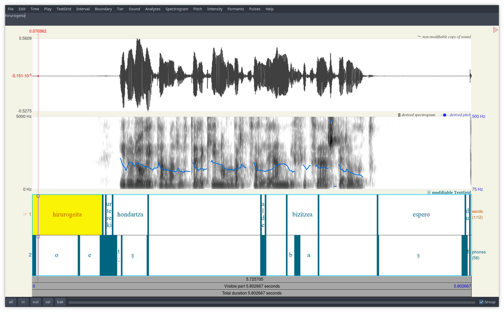

We validate again the new corpus (adapt the paths):

```python
!mfa validate --clean ~/Workspace/corpora/Basque_multi-speaker_dataset/ basque_cv
```

```
WARNING - The previous run had a different configuration than the current, which
                   may cause issues. Please see the log for details or use
                   --clean flag if issues are encountered.
INFO - Setting up corpus information...
INFO - Loading corpus from source files...
INFO - Found 52 speakers across 618 files, average number of utterances per
                speaker: 11.884615384615385
INFO - Initializing multiprocessing jobs...
INFO - Normalizing text...
INFO - Creating corpus split for feature generation...
INFO - Generating MFCCs...
619it [00:07, 87.32it/s]
INFO - Calculating CMVN...
INFO - Generating final features...
INFO - Creating corpus split with features...

INFO - ******
INFO - Corpus
INFO - ******

INFO -   618 sound files
INFO -   618 text files
INFO -   52 speakers
INFO -   618 utterances
INFO -   3844.608 seconds total duration

INFO -   Sound file read errors
INFO -   ======================

INFO -     There were no issues reading sound files.

INFO -   Feature generation
INFO -   ==================

INFO -     There were no utterances missing features.

INFO -   Files without transcriptions
INFO -   ============================

INFO -     There were no sound files missing transcriptions.
```

[output cut: 124 more lines]

```
INFO - Accumulating statistics...
INFO - monophone - Iteration 39 of 40
INFO - Accumulating statistics...
INFO - monophone - Iteration 40 of 40
INFO - Accumulating statistics...
INFO - Training complete!
INFO - Compiling training graphs...
INFO - Generating alignments...
INFO - Accumulating transition stats...
INFO - Finished accumulating transition stats!
INFO - Beginning phone LM training...
INFO - Collecting training data...
INFO - Training model...
INFO - Completed training in 180.79399728775024 seconds!
INFO - Done! Everything took 200.403 seconds
```

This looks way better: we have now a corpus of ~65 minutes and again, no missing transcriptions or sound files and no oov words. We start the training again, but we will change the name of the acoustic model into My_Basque_AC_model2.zip

```python
!mfa  train --clean ~/Workspace/corpora/Basque_multi-speaker_dataset/ basque_cv ~/Workspace/corpora/My_Basque_AC_model2.zip
```

```
WARNING - The previous run had a different configuration than the current, which
                   may cause issues. Please see the log for details or use
                   --clean flag if issues are encountered.
INFO - Setting up corpus information...
INFO - Loading corpus from source files...
INFO - Found 52 speakers across 618 files, average number of utterances per
                speaker: 11.884615384615385
INFO - Initializing multiprocessing jobs...
INFO - Normalizing text...
INFO - Creating corpus split for feature generation...
INFO - Generating MFCCs...
619it [00:07, 87.67it/s]
INFO - Calculating CMVN...
INFO - Generating final features...
INFO - Creating corpus split with features...
INFO - Initializing training for monophone...
INFO - Compiling training graphs...
INFO - Generating initial alignments...
INFO - Initialization complete!
INFO - monophone - Iteration 1 of 40
INFO - Generating alignments...
INFO - Accumulating statistics...
INFO - monophone - Iteration 2 of 40
INFO - Generating alignments...
INFO - Accumulating statistics...
INFO - monophone - Iteration 3 of 40
INFO - Generating alignments...
INFO - Accumulating statistics...
INFO - monophone - Iteration 4 of 40
INFO - Generating alignments...
INFO - Accumulating statistics...
INFO - monophone - Iteration 5 of 40
INFO - Generating alignments...
INFO - Accumulating statistics...
INFO - monophone - Iteration 6 of 40
INFO - Generating alignments...
INFO - Accumulating statistics...
INFO - monophone - Iteration 7 of 40
INFO - Generating alignments...
INFO - Accumulating statistics...
```

[output cut: 527 more lines]

```
INFO - Training complete!
INFO - Exiting training early to save time as the corpus is below the subset
                size for later training stages
INFO - Compiling training graphs...
INFO - Generating alignments...
INFO - Calculating fMLLR for speaker adaptation...
INFO - Generating alignments...
INFO - Accumulating transition stats...
INFO - Finished accumulating transition stats!
INFO - Beginning phone LM training...
INFO - Collecting training data...
INFO - Training model...
INFO - Completed training in 1449.2726023197174 seconds!
INFO - Saved model to /home/philipp/Workspace/corpora/My_Basque_AC_model2.zip
INFO - Done! Everything took 1469.613 seconds
```

After the acoustic model training is complete, we align our multi-spaker data using the new acoustic model:

```python
!mfa align --clean ~/Workspace/corpora/Basque_multi-speaker_dataset/ basque_cv ~/Workspace/corpora/My_Basque_AC_model2.zip ~/Workspace/corpora/Basque_multi-speaker_alignments/
```

[output not shown]

[output cut: 46 more lines]

[output not shown]

The resultsing TextGrids look like this:

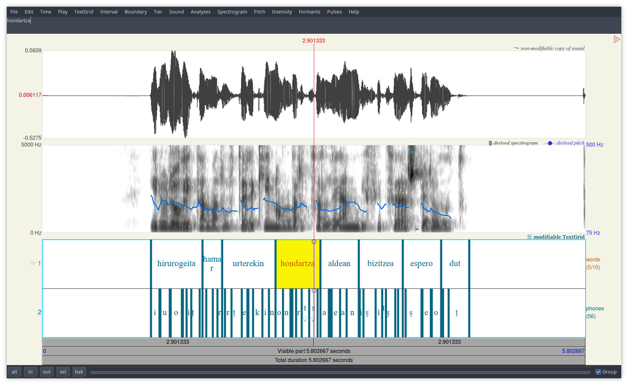

And this is way better than the alignments we had before. However, if you inspect the TextGrids in more detail, you will see that the phone alignments are far from being perfect. There are multiple reasons for this: First, the aligner was run with the standard settings for training. The acoustic model and the following aligning procedure can be improved by modifying these settings. We did not talk about this so far, but if you are interested, see [here](https://montreal-forced-aligner.readthedocs.io/en/latest/user_guide/configuration/acoustic_modeling.html). Anyway, the standard settings should be sufficient in most cases. A second reason is that although we used at least 1 hour of data for training, more data is better. The last reason is that this data his highly variable, meaning that we have a lot of different utterances used for training. While this is good especially if we have more data, it may be a disadvantage with a comparatively small dataset. However, if you have a lot of data from an experiment, 1 hour may be sufficient since there is not that much variability in the training data.